# Viés De Estimadores em Análise de Sobrevivência Controlando o Percentual de Censura: um Estudo por Simulação de Monte Carlo

# 1 Introdução

Em análise de sobrevivência, a variável resposta é, geralmente, o tempo até a ocorrência de um evento de interesse. Este tempo é denominado **tempo de falha**, podendo ser o tempo até a morte do paciente, bem como o tempo (ou quilometragem) até a falha de um componente de um veículo automotivo.

A principal característica de dados de sobrevivência é a presença de **censura**, que é a observação parcial da resposta devido ao término do estudo antes que todos os indivíduos sob estudo venham a falhar: dados censurados nos dizem que o tempo até a falha é superior àquele observado. Sem a presença de censura, as técnicas estatísticas clássicas, como inferência, análise de regressão e planejamento de experimentos poderiam ser utilizadas na análise deste tipo de dados. A falta da possibilidade de observação completa das informações de evento das unidades amostrais faz necessário o uso dos métodos de análise de sobrevivência que possibilitam incorporar na análise estatística a informação contida nos dados censurados.

Dentre alguns tipos de censura existentes, há o de caráter aleatório que ocorre, por exemplo, quando um paciente é retirado no decorrer do estudo sem ter ocorrido a falha (ou quando o paciente morre por uma razão diferente da estudada).

Uma representação simples do mecanismo de **censura aleatória** é feita utilizando duas variáveis aleatórias:

Se:

$$T: \text{Tempo até a falha}$$

$$C: \text{Tempo de censura}$$

Então:

$$t = min(T, C) \text{ é o tempo observado}$$

e

$$\delta =
\begin{cases}
1, & \text{se } & T \leq C \\
0, & \text{se } & T > C
\end{cases}
\text{ é o indicador de de censura.}$$

Para uma amostra de tamanho n, os dados de sobrevivência para o i-ésimo indivíduo (i = 1, 2, …, n) são representados da seguinte forma:

$$\delta_i =
\begin{cases}
1, & \text{se } t_i \text{ é um tempo de falha (}T \leq C \text{)}\\
0, & \text{se } t_i \text{ é um tempo censurado (}T > C \text{)}
\end{cases}$$

A variável aleatória T deve ser uma não-negativa, usualmente contínua (exponencial, weibull, log-normal, gamma, gamma generalizada, etc.). Geralmente, T é especificada pela sua função de sobrevivência:

$$S(t) = P(T \geq t) = 1 - F(t) \text{ é a função de sobrevivência}$$
e
$$F(t) \text{ é a função de distribuição acumulada da distribuição de probabilidade que descreve a v.a. T.}$$
Assumimos que a variável aleatória T segue uma distribuição de probabilidade com suporte estritamente positivo a qual não conhecemos os parâmetros. Tais, portanto, devem ser estimados a partir das observações amostrais para determinação do modelo probabilístico. Neste estudo, utiliza-se o **Método de Máxima Verossimilhança** implementada no pacote `survival` da linguagem de programação R para a estimação dos parâmetros.

A expressão para a função de verossimilhança para o mecanismo aleatório de censura é dada por:

$$L(\theta) \propto \prod_{i=1}^{n} f(t_i;\theta)^{\delta_i} \, S(t_i;\theta)^{1 - \delta_i}$$
conforme demonstrado na literatura de análise de sobrevivência (COLOSIMO; GIOLO, 2021).

# 2 Motivação

O presente estudo tem como objetivo avaliar o viés de estimadores de parâmetros de uma distribuição de probabilidade e da função de sobrevivência S(t) em função do percentual de censura presente nos dados. Para isso, é realizada uma simulação de Monte Carlo, onde são geradas amostras aleatórias com diferentes percentuais de censura, e os parâmetros da distribuição de probabilidade e a função de sobrevivência são estimados utilizando o método de máxima verossimilhança. O viés relativo é então calculado para avaliar a precisão dos estimadores em relação aos parâmetros verdadeiros variando o percentual de censura em amostras descritas por diferentes distribuições de probabilidade estritamento positivas, a saber: exponencial, weibull-2p, log-normal, gama generalizada.

# 3 Simulação

Para este estudo, fez-se necessário a utilização do Método de Simulação de Monte Carlo com implementação na linguagem de progamação R para condução das análises. O processo de simulação é descrito a seguir.

## 3.1 Algoritmo

Uma simulação consiste de:

1. Definir as **distribuições e parâmetros de** $T$ **e** $C$;
2. Estabelecer um **grid de pontos percentuais** $\tau$;
3. Fixar um percentual de censura $\tau$;
4. Gerar **B amostras aleatórias de tamanho** $n$ com dados de sobrevivência a partir de $T$ e $C$ condicionados a $\tau$;
5. Estimar os parâmetros do modelo para cada simulação $B$ via **Máxima Verossimilhança** (**EMV)**;
6. Calcular o **viés relativo do(s) parâmetro(s) e** $\hat{S}(t)$ ponto a ponto contra a curva teórica;
7. Obter o **viés relativo global** para o referido $\tau$;
8. Repetir o processo para **todos os** $\tau$ definidos no grid.

## 3.2 Configuração

$$\# \tau = 100 \text{ (diferentes pontos percentuais de censura)}$$

$$B = 1000 \text{ (simulações)}$$

$$n = 1000 \text{ (unidades amostrais)}$$

### 3.2.1 T ~ Exp( $\lambda$ )

$$\lambda = 0.3$$

### 3.2.2 T ~ Weibull( $k$ , $\lambda$ )

$$k = 3$$

$$\lambda = 0.3$$

### 3.2.3 T ~ LN( $\mu$, $\sigma$ )

$$\mu = 3$$

$$\sigma = 0.3$$

### 3.2.4 T ~ GG( $k$, $\lambda$, $Q$ )

$$k = 3$$

$$\lambda = 0.3$$

$$Q = 3$$

## 3.3 Grid de Percentuais de Censura

```r
# Gera grid para theta a fim o obter percentuais de censura
# distribuídos de forma quase equilibrada entre 0 e 1.
theta_grid <- exp(seq(log(0.001), log(1e3), length.out = n_cens_perc))

# Calcula percentuais de censura para cada valor de theta
cens_grid <- sapply(theta_grid, calc_cens)

# Organiza dados para obter a função de calibração entre theta e censura
df_calib <- data.frame(
  cens = cens_grid,
  theta = theta_grid
) |>
  arrange(cens) |>
  group_by(cens) |>
  summarise(theta = mean(theta), .groups = "drop")

# Obtém o theta correspondente a cada percentual de censura
# Obs.: Usa-se interpolação linear
theta_from_cens <- function(target_cens){
  approx(
    x = df_calib$cens,
    y = df_calib$theta,
    xout = target_cens,
    rule = 2
  )$y
}

# Obtém o theta linearmante interpolado correspondente
# Obs.: para cada percentual de censura desejado
cens_targets <- seq(0.05, 0.95, length.out = n_cens_perc)
theta <- sapply(cens_targets, theta_from_cens)
```

## 3.4 Geração de Amostras Aleatórias

```r
aa.exp <- function(n, lambda, theta) {

  # Tempos até o evento
  T_ <- rexp(n = n, rate = 1/lambda)

  # Tempos de censura
  C_ <- runif(n, min = 0, max = theta)

  # Tempos Observados
  tempos <- pmin(T_, C_)
  # Indicador de censura
  cens <- as.integer(T_ <= C_)
  # Tempos observados com indicador de censura
  X <- cbind(tempos, cens) |> as.data.frame()
  colnames(X) <- c("time", "event")

  return(X)
}
```

## 3.5 Estimação da Função de Sobrevivência S(t)

```r
fit.exp <- function(n = n, lambda = lambda, theta = theta){

  # Gera amostra aleatória
  X <- aa.exp(n = n, lambda = lambda, theta = theta)

  # Ajusta parâmetros usando MLE
  fit <- flexsurvreg(
    Surv(time, event) ~ 1
    ,data = X
    ,dist = "exponential"
  )

  # Extraindo estimativas pontuais
  lambda_hat <- 1/exp(fit$coefficients[1])

  # Percentual de censura
  cens_perc <- mean(1 - X$event)

  # Retorna as estimativas pontuais
  return(c(c = cens_perc, lambda = lambda_hat))
}
```

## 3.6 Cálculo do Viés Relativo

O cálculo do viés foi realizado integrada para cada ponto um fixo grid temporal $t$ variando do tempo zero até o percentil 99% da distribuição teórica ($t_{0.99}$). A avaliação do viés adota a métrica do Viés Relativo Médio ao longo do tempo (MRE) para a sobrevivência:

$$\text{Viés}(\hat{\theta}) = \frac{1}{B}\sum_{b=1}^{B} \left( \frac{\hat{\theta}_b - \theta}{\theta} \right)$$
$$\text{Viés}(\hat{S}(t)) = \text{Mean}_t \left( \frac{\frac{1}{B}\sum_{j=1}^{B}\hat{S}_j(t) - S(t)}{S(t)} \right)$$

```r
# Definindo um grid de valores de t
t_exp <- seq(0, quantile(rexp(1e5, rate = 1/lambda), 0.99), length.out = 1e4)
```

```r
S_t_teorica_exp <- pexp(q = t_exp, rate = 1/lambda, lower.tail = FALSE)
```

```r
# Função de sobrevivência estimada
S_t_estimada_exp <- function(t, lambda){
  pexp(q = t, rate = 1/lambda, lower.tail = FALSE)
}
```

```r
sim_exp <- function(B, n, lambda, theta){

  # Gerando amostras e estimando
  params_ams_exp <- replicate(
    B,
    fit.exp(
      n = n,
      lambda = lambda,
      theta = theta
    )
  ) |> t()

  # Estimando S(t) para cada simulação
  S_t_estimado_ams_exp <- sapply(
    params_ams_exp[, "lambda"]
    ,function(lambda) S_t_estimada_exp(t_exp, lambda)
  )
  S_t_estimado_ams_mean_exp <- rowMeans(S_t_estimado_ams_exp)

  # Estimando o viés
  cens_perc <- mean(params_ams_exp[, "c"])
  bias_S_t <- mean(S_t_estimado_ams_mean_exp/S_t_teorica_exp - 1)
  bias_lambda <- mean(params_ams_exp[, "lambda"]/lambda - 1)

  return(c(c = cens_perc, bias_S_t = bias_S_t, bias_lambda = bias_lambda))

}
```

## 3.7 Execução da Simulação

```r
res_exp <- future_sapply(
  theta,
  function(x) {
    sim_exp(
      B = B,
      n = n,
      lambda = lambda,
      theta = x
    )
  },
  future.seed = TRUE
)
```

*“Para cada* $\tau$*% de censura, simulamos B amostras de tamanho n de dados de sobrevivência descritas pelas v.a.’s T e C, e calculamos o viés relativo de* $\hat{S(t)}$ *e respectivos parâmetros. Assim, para cada* $\tau$*% de censura temos um viés.”*

## 3.8 Resultados

### 3.8.1 T ~ Exp( $\lambda$ = 0.3)

[interactive chart not shown]

### 3.8.2 T ~ Weibull( $k$ = 3, $\lambda$ = 0.3)

[interactive chart not shown]

### 3.8.3 T ~ LN( $\mu$ = 3, $\sigma$ = 0.3)

[interactive chart not shown]

### 3.8.4 T ~ GG( $k$ = 3 , $\lambda$ = 0.3, $Q$ =3)

[interactive chart not shown]

# 4 Estudo de Caso: Comparando Amostras com Diferentes % de Censura

## 4.1 Configurações

Baseado no esquema de simulação demonstrado anteriormente, conduzir-se-á, a partir de agora, uma análise detalhada com as seguintes configurações:

- T ~ Exp($\lambda$ = 0.3);
- C ~ U(0, $\theta$($\tau$));
- $\tau$ = (0.25, 0.75)
- n = 1000
- B = 10000 (simulações)

```r
B <- 1e4

n <- 1e3

lambda <- 0.3

cens_targets <- c(0.25, 0.75)
```

Para tanto, os seguintes pacotes serão utilizados:

- `tidyverse` para transformação de dados em objeto `data.frame`;
- `survival` e `flexsurv` para ajuste dos parâmetros do modelo paramétrico para a função de sobrevivência;
- `tseries` para realizar o teste de Jarque-Bera;
- `moments` para calcular a assimetria e coeficiente de curtose para suportar o teste de normalidade da distribuição amostral do estimador de lambda.

```r
library(tidyverse)
library(survival)
library(flexsurv)
library(moments)
library(tseries)
```

## 4.2 Grid de Percentuais de Censura

O primeiro passo é encontrar os dois valores de $\theta$ tais que consigamos amostrar dados de sobrevivência com $\tau$ = (25%, 75%) de censura. O código é o mesmo apresentado em Grid de Percentuais de Censura

```r
n_cens_perc <- 1e2

theta_grid <- exp(seq(log(0.001), log(1e3), length.out = n_cens_perc))

calc_cens <- function(theta, n = 20000){
  T_ <- rexp(n, rate = 1/lambda)
  C_ <- runif(n, 0, theta)
  mean(C_ < T_)
}

cens_grid <- sapply(theta_grid, calc_cens)

df_calib <- data.frame(
  cens = cens_grid,
  theta = theta_grid
) |>
  arrange(cens) |>
  group_by(cens) |>
  summarise(theta = mean(theta), .groups = "drop")

theta_from_cens <- function(target_cens){
  approx(
    x = df_calib$cens,
    y = df_calib$theta,
    xout = target_cens,
    rule = 2
  )$y
}

theta <- sapply(cens_targets, theta_from_cens)

print(cbind(
  cens = cens_targets,
  theta = theta
))
```

```
     cens     theta
[1,] 0.25 1.1721997
[2,] 0.75 0.1823458
```

Para verificar a consistência dos valores obtidos para $\theta$ para com os valores de $\tau$ definidos, foram geradas aleatoriamente 100000 amostras de tamanho 1000 de dados de sobrevivência e obtidos os percentuais de censura correspondentes. Os valores abaixo representam a média para cada um dos $\theta$ encontrados. Observa-se a consistência dos valores obtidos pois os percentuais de censura médios convergem para os 25% e 75% esperados:

```r
# Percentuais de censura reais utilizados
mean(replicate(1e5,mean(runif(1e3, 0, theta[1]) < rexp(1e3, rate = 1/lambda))))
```

```
[1] 0.2507761
```

```r
mean(replicate(1e5,mean(runif(1e3, 0, theta[2]) < rexp(1e3, rate = 1/lambda))))
```

```
[1] 0.7493539
```

## 4.3 Amostras Aleatórias

Para gerar amostras aleatórias de dados de sobrevivência para cada um dos percentuais de censura, foi utilizado o código apresentado em Geração de Amostras Aleatórias

```r
aa.exp <- function(n, lambda, theta) {

  # Tempos até o evento
  T_ <- rexp(n = n, rate = 1/lambda)

  # Tempos de censura
  C_ <- runif(n, min = 0, max = theta)

  # Tempos Observados
  tempos <- pmin(T_, C_)
  # Indicador de censura
  cens <- as.integer(T_ <= C_)
  # Tempos observados com indicador de censura
  X <- cbind(tempos, cens) |> as.data.frame()
  colnames(X) <- c("time", "event")

  return(X)
}

fit.exp <- function(n = n, lambda = lambda, theta = theta){

  # Gera amostra aleatória
  X <- aa.exp(n = n, lambda = lambda, theta = theta)

  # Modelo Paraamétrico: Distribuição Gamma Generalizada
  # Ajusta parâmetros usando MLE
  fit <- flexsurvreg(
    Surv(time, event) ~ 1
    ,data = X
    ,dist = "exponential"
  )

  # Extraindo estimativas pontuais
  lambda_hat <- 1/exp(fit$coefficients[1])

  # Percentual de censura
  cens_perc <- mean(1 - X$event)

  # Retorna as estimativas pontuais
  return(c(c = cens_perc, lambda = lambda_hat))
}

lambda_hat_ams25 <- replicate(B, fit.exp(n, lambda, theta[1]))
lambda_hat_ams75 <- replicate(B, fit.exp(n, lambda, theta[2]))
```

## 4.4 Análise dos Parâmetros

Percentuais de censura médio observados nas amostras geradas anteriormente:

```r
# Percentual de censura observado (esperado de 25%)
lambda_hat_ams25[1, ] %>% mean()
```

```
[1] 0.250675
```

```r
# Percentual de censura observado (esperado de 75%)
lambda_hat_ams75[1, ] %>% mean()
```

```
[1] 0.7493555
```

Estimativas pontuais obtidas a partir das amostras de cada um dos percentuais de censura. Aqui já se observar um maior viés de $\hat{\lambda}_\text{75% censura}$ em relação a $\hat{\lambda}_\text{25% censura}$:

```r
# Estimativa do parâmetro lambda para 25% de censura
lambda_hat_ams25[2, ] %>% mean()
```

```
[1] 0.2999736
```

```r
# Estimativa do parâmetro lambda para 75% de censura
lambda_hat_ams75[2, ] %>% mean()
```

```
[1] 0.3010622
```

A fim de estudar a característica das distribuições amostrais de $\hat{\lambda}_\text{25% censura}$ e $\hat{\lambda}_\text{75% censura}$, foi plotado os respectivos histogramas, realizado teste de normalidade de Jarque-Bera e obtido os coeficientes de assimetria e curtose. Apesar de visualmente dar a entender seguirem distribuições normais, o teste de normalidade de Jarque-Bera sugere o oposto, rejeitando a hipótese nula. Para $\hat{\lambda}_\text{75% censura}$, é possível observar uma assimetria a direita, sustentado por respectivos maiores coeficientes de assimetria e curtose.

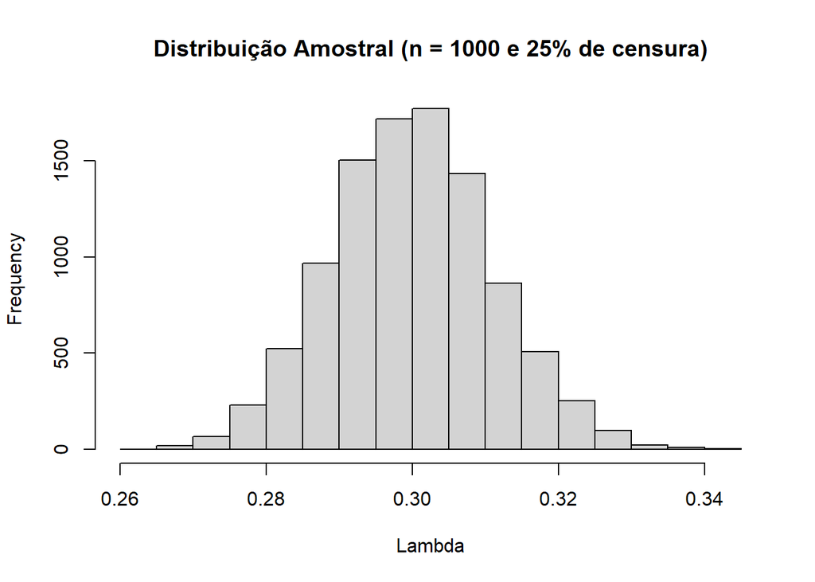

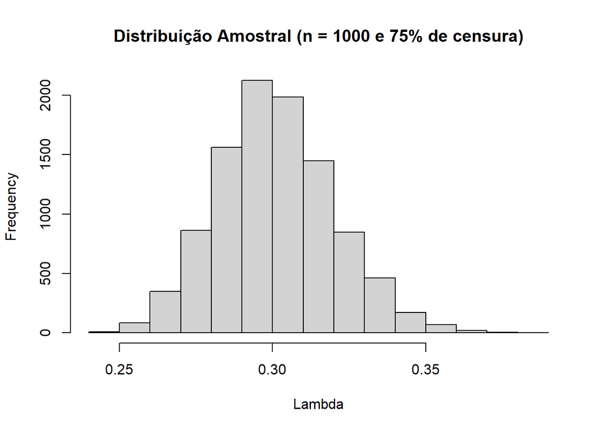

Para amostras com ~25% de censura:

```r
# Testa se a distribuições amostrais são normais
tseries::jarque.bera.test(lambda_hat_ams25[2, ])
```

```
    Jarque Bera Test

data:  lambda_hat_ams25[2, ]
X-squared = 17.399, df = 2, p-value = 0.0001667
```

```r
skewness(lambda_hat_ams25[2, ])
```

```
[1] 0.1021599
```

```r
kurtosis(lambda_hat_ams25[2, ])
```

```
[1] 3.00324
```

Para amostras com ~75% de censura:

```r
# Testa se a distribuições amostrais são normais
tseries::jarque.bera.test(lambda_hat_ams75[2, ])
```

```
    Jarque Bera Test

data:  lambda_hat_ams75[2, ]
X-squared = 143.95, df = 2, p-value < 2.2e-16
```

```r
skewness(lambda_hat_ams75[2, ])
```

```
[1] 0.2837574
```

```r
kurtosis(lambda_hat_ams75[2, ])
```

```
[1] 3.152967
```

Ademais, obseva-se que $\hat{\lambda}_\text{75% censura}$ apresenta variância maior relativa a $\hat{\lambda}_\text{25% censura}$, sugerindo que maiores percentuais de censura em amostras de dados de sobrevivência geram estimativas menos consistentes não apenas em função do maior viés, mas também devido a maior variância.

Para amostras com ~25% de censura:

```r
var(lambda_hat_ams25[2, ])
```

```
[1] 0.0001206257
```

```r
(MSE25 <- var(lambda_hat_ams25[2, ]) + (mean(lambda_hat_ams25[2, ]) - lambda)^2)
```

```
[1] 0.0001206264
```

Para amostras com ~75% de censura:

```r
var(lambda_hat_ams75[2, ])
```

```
[1] 0.0003655794
```

```r
(MSE75 <- var(lambda_hat_ams75[2, ]) + (mean(lambda_hat_ams75[2, ]) - lambda)^2)
```

```
[1] 0.0003667077
```

```r
MSE75/MSE25
```

```
[1] 3.040029
```

Aqui, visualiza-se a convergência dos estimadores $\hat{\lambda}_\text{25% censura}$ e $\hat{\lambda}_\text{75% censura}$. Observa-se que ambos são viesados, afinal, ambos são censurados e, portanto, possuem informações parciais do tempo de falha; mas, é nítido que $\hat{\lambda}_\text{75% censura}$ superestima mais.

[interactive chart not shown]

## 4.5 Análise de S(t)

Com o intuito de visualizar o impacto dos diferentes percentuais de censura na estimativa de $S(t)$, plotou-se o viés relativo de $S(t)$ para uma sequência de pontos de tempo de vida. Nota-se que as estimativas de $S_\text{25% censura}(t_i)$ são mais consistentes ao longo do tempo de vida. Entretanto, é nítido a presença de superestimativas na cauda da distribuição. Além disso, $S_\text{25% censura}(t_i)$ apresenta viéses cada vez maiores ao longo de t.

```r
t_exp <- seq(0, quantile(rexp(1e5, rate = 1/lambda), 0.99), length.out = 1e3)

S_t_teorica_exp <- pexp(q = t_exp, rate = 1/lambda, lower.tail = FALSE)
df_teo <- data.frame(
  t = t_exp,
  S = S_t_teorica_exp
)

S_t_estimada_exp <- function(t, lambda){
  pexp(q = t, rate = 1/lambda, lower.tail = FALSE)
}

# 25% de censura
S_t_estimado_ams25_exp <- sapply(
  lambda_hat_ams25[2, ]
  ,function(lambda) S_t_estimada_exp(t_exp, lambda)
)
S_t_estimado_ams25_mean_exp <- rowMeans(S_t_estimado_ams25_exp)
S_t_estimado_ams25_mean_exp_bias <- data.frame(
  t = t_exp,
  bias_r = S_t_estimado_ams25_mean_exp/S_t_teorica_exp - 1,
  c = rep("25%", length(t_exp)))

# 75% de censura
S_t_estimado_ams75_exp <- sapply(
  lambda_hat_ams75[2, ]
  ,function(lambda) S_t_estimada_exp(t_exp, lambda)
)
S_t_estimado_ams75_mean_exp <- rowMeans(S_t_estimado_ams75_exp)
S_t_estimado_ams75_mean_exp_bias <- data.frame(
  t = t_exp,
  bias_r = S_t_estimado_ams75_mean_exp/S_t_teorica_exp - 1,
  c = rep("75%", length(t_exp)))
```

[interactive chart not shown]

# 5 Conclusões

O viés relativo dos estimadores de parâmetros e da função de sobrevivência S(t) tende a aumentar à medida que o percentual de censura cresce, indicando que a presença de censura pode introduzir um viés significativo na estimação dos parâmetros e da função de sobrevivência. Entretanto, obaserva-se um viés baixo para percentuais de censura até entre 50 e 70%, o que sugere que os estimadores podem ser relativamente robustos a níveis moderados de censura.

Destaca-se que as estimativas para a função de sobrevivência resultante de uma distribução Weibull foi a menos viesada e também com menor dispersão em torno de 0 para maiores percentuais de censura, conseguindo chegar a resultados consistentes para até ~88% de censura, mas apresentando o pior resultado além desse percentual quando comparado com as outras distribuições.

Vale ressaltar que o modelo da Gama Generalizada, apesar de ser o mais flexível entre todos, apresenta uma clara tendência crescente para o viés relativo dos parâmetros e função de sobrevivência, sugerindo a importância de utilizar o modelo mais simples sempre quando possível.

# 6 Recomendações para estudos futuros

Para estudos futuros:

- Realizar o mesmo estudo variando o tamanho n da amostra e comparar o comportamento do viés;
- Calcular o viés relativo para o estimador não-paramétrico de Kaplan-Meier e comparar com as estimativas paramétricas;
- Reciclar o código visando otimizar o tempo de execução do algoritmo de simulação.

# 7 Referências

Códigos utilizados disponíveis em: https://github.com/victorpietchakiUFPR/UFPR_DEST_CE312_Estudo_de_Simulacao

COLOSIMO, Enrico A.; GIOLO, Suely R. Análise de sobrevivência aplicada. 2. ed. São Paulo: Blucher, 2021. (Coleção Projeto Fisher).

RIBEIRO JUNIOR, Paulo Justiniano; MAYER, Fernando Pol. Materiais da disciplina CE312. Curitiba: LEG/DEST/UFPR. Disponível em: http://www.leg.ufpr.br/~paulojus/CE312/materiais.html. Último acesso em: 26 abr. 2026.